# Web Scraping with R (1): Parsing HTML

Alex Sanchez (asanchez@ub.edu)  
GME Department. Universitat de Barcelona  
Statistics and Bioinformatics Unit. Vall d’Hebron Institut de Recerca

XII MESIO Summer School (2018)

# Readme

- License: Creative Commons Attribution-NonCommercial-ShareAlike 4.0 International License http://creativecommons.org/licenses/by-nc-sa/4.0/
- You are free to:
  - **Share** : copy and redistribute the material
  - **Adapt** : rebuild and transform the material
- Under the following conditions:
  - **Attribution** : You must give appropriate credit, provide a link to the license, and indicate if changes were made.
  - **NonCommercial** : You may not use this work for commercial purposes.
  - **Share Alike** : If you remix, transform, or build upon this work, you must distribute your contributions under the same license to this one.

# Disclaimer and acknowledgements

- These slides have been prepared based on multiple sources: websites, blogs, courses. While it is hard to cite them all I wish to acknowledge those sources that have been particularly useful.
  - [Tutorial-R-web-data](https://github.com/gastonstat/tutorial-R-web-data), by Gaston Sanchez
  - [Text Mining, Scraping and Sentiment Analysis with R](https://www.udemy.com/r-social-media-mining-scraping-with-twitter/) Udemy.
  - [Working with Web Data in R](https://www.datacamp.com/courses/working-with-web-data-in-r) Datacamp Course

# Introduction

- In web scraping, we usually get in touch with HTML in two steps:
  - First, we inspect content on the Web and examine whether it is attractive for further analyses.
  - Second, we import HTML files into R and extract information from them.
- Parsing HTML occurs at both steps
  - *by the browser* to display HTML content nicely, and also
  - *by parsers in R* to construct useful representations of HTML documents in our programming environment.

# What is *parsing*

- Parsing involves *breaking down a text into its component parts of speech with an explanation of the form, function, and syntactic relationship of each part*. [Wikipedia](https://en.wikipedia.org/wiki/Parsing).
- The difference between reading and parsing is not just a semantic one:
  - **reading** is made using (reading) functions that *do not care to understand the formal grammar that underlies HTML* but merely recognize the sequence of symbols included in the HTML file.
  - **parsing** is made employing programs that understand the special meaning of the mark-up structure and reconstructs the implied HTML hierarchy of an HTML file within some R-specified structure.

# Getting data (1): **Reading** an HTML file

- We can read a file from the web using `readlines()` function:

```r
url <- "http://www.r-datacollection.com/materials/html/fortunes.html"
fortunes <- readLines(con = url)
head(fortunes, n=10)
```

```
##  [1] "<!DOCTYPE HTML PUBLIC \"-//IETF//DTD HTML//EN\">"
##  [2] "<html> <head>"
##  [3] "<title>Collected R wisdoms</title>"
##  [4] "</head>"
##  [5] ""
##  [6] "<body>"
##  [7] "<div id=\"R Inventor\" lang=\"english\" date=\"June/2003\">"
##  [8] "  <h1>Robert Gentleman</h1>"
##  [9] "  <p><i>'What we have is nice, but we need something very different'</i></p>"
## [10] "  <p><b>Source: </b>Statistical Computing 2003, Reisensburg"
```

- `readLines()`
  - maps every line of the input file to a separate value in a character vector creating a flat representation of the document.
  - is *agnostic* about the different tag elements (name, attribute, values, etc.) and produces results that do not reflect the document’s internal hierarchy *as implied by the nested tags* in any sensible way.

# Getting data (2): Parsing an HTML file

- To achieve a useful representation of HTML files, we need to employ a program that
  - understands the special meaning of the markup structures and
  - reconstructs the implied hierarchy of an HTML file within some R-specific data structure.
- This representation is also referred to as the *Document Object Model (DOM)*.
  - A Document Object Model is a queryable data object that we can build from any HTML file and is useful for further processing of document parts.

# A distraction: HTML tree structure

- If one ignores the <!DOCTYPE html > tag it is easy to see that an HTML document can be seen as a hierarchichal collection of tags which contain distinct elements.
- This can also be visualised as a tree.

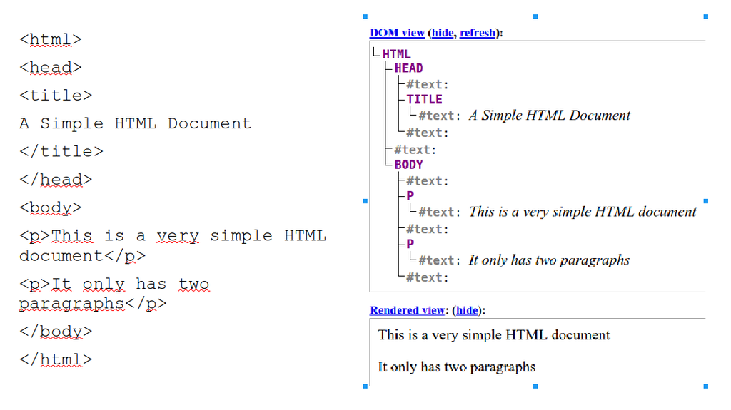

- Hint: Copy the source code of the `fortunes.html` document and paste it in [This viewer](https://software.hixie.ch/utilities/js/live-dom-viewer/)

# DOM-style parsers

- Transformation from HTML code to the DOM is the task of a *DOM-style parser*.
- Parsers belong to a *general class of domain-specific programs that traverse over symbol sequences and reconstruct the semantic structure of the document within a data object of the programming environment*.
- Right now there are two mainstream packages that can be used for parsing HTML code
  - [XML package](https://cran.r-project.org/web/packages/XML/index.html) by Duncan Temple and Debbie Nolan,
  - [rvest package](https://github.com/hadley/rvest) by Hadley Wickam,
  - and a few others that one can see at [CRAN Task View: Web Technologies and Services](https://cran.r-project.org/web/views/WebTechnologies.html).
  - See also the table and introduction at: (An R web crawler and scraper)[https://github.com/salimk/Rcrawler]

# Scrapping web pages (I): Using the `XML` package

- The `XML` package provides an interface to `libxml2` a powerful parsing library written in C.
- The package is designed for two main purposes
  - parsing xml / html content
  - writing xml / html content (*we wonn’t cover this*)

# What can we do with “XML”?

- We cover 4 major types of tasks that can be performed with “XML”
1. parsing xml / html content
2. obtaining descriptive information about parsed contents
3. navigating the tree structure (ie *accessing its components*)
4. querying and extracting data from parsed contents
- XML package can be used for both XML and HTML parsing.
- We will see how to use it, later in the course, when we work with XML files.

# Scraping web pages (II): Using the `rvest` package

- `rvest`is an R package written by the R guru [Hadley Wickam](http://hadley.nz/).
- It is intended to facilitate the process of acquiring data from web pages (not “from the web”) and parsing the result into R.
- rvest is inspired to work with magrittr
- See more information on `rvest` at:
  - [rvest package on Github](https://github.com/hadley/rvest)
  - [rvest documentation on CRAN](http://cran.r-project.org/web/packages/rvest/index.html)
  - [rstudio blog on rvest](http://blog.rstudio.org/2014/11/24/rvest-easy-web-scraping-with-r/)

# Basic rvest capabilities

- Get the data: Create an html document from a url, a file on disk or a string containing html with `read_html()`.
- Select parts of an html document using css selectors: `html_nodes()` (Read vignette with: `vignette("selectorgadget")` after installing and loading rvest in R.
- Extract components with
  - `html_tag()` (the name of the tag),
  - `html_text()` (all text inside the tag),
  - `html_attr()` (contents of a single attribute) and
  - `html_attrs()` (all attributes). These are done after using `html_nodes()`.
- Parse tables into data frames with `html_table()`.
- Extract, modify and submit forms with `html_form()`, `set_values()` and `submit_form()`.
- Detect and repair encoding problems with `guess_encoding()` and `repair_encoding()`. Then pass the correct encoding into `html()` as an argument.

# `rvest`by the example (1): Grab the data

- Imagine we want to extract information from a certain movie on imdb, “The Lego Movie”

The Lego Movie

```r
install.packages("rvest", dependencies=TRUE)
require(rvest)
lego_movie <- read_html("http://www.imdb.com/title/tt1490017/")
```

# `rvest` by the example (2): parse the data

- We start extracting the **movie rating**. Now we have the data we need to figure out which *selector* matches the data we want.
  - Examining the page with *selectorgadget* we find that it is `strong span`
- We now:
  - use `html_node()` to find the first node that matches that selector,
  - extract its contents with `html_text()`, and
  - convert it to numeric with `as.numeric()`

```r
rating <- lego_movie %>%
  html_node("strong span") %>%
  html_text() %>%
  as.numeric()
rating
```

# `rvest` by the example (3): keep parsing

- Use a similar process to extract the cast, using `html_nodes()` to find all nodes that match the selector:

```r
cast <- lego_movie %>%
  html_nodes("#titleCast .itemprop span") %>%
  html_text()
cast
```

- Or we can extract the image:

```r
poster <- lego_movie %>%
  html_nodes(".poster img") %>%
  html_attr("src")
poster
```

# It’s your turn now!

- Write a script to find out which actor appears in higher number of Star War movies.
- Hint: The idea is similar to the previous exercise but with a litlle more work you can
1. Start in a page that gives you access to the list of Star Wars Films (try googling “Star Wars IMDB”)
2. From here write a function to extract the authors list from an IMDB whose URL is providd
3. Apply the function to the URLs list and
4. Tabulate or plot

# To learn more …

- Additional tutorials on web scrapping based on the `rvest` package:
  - http://zevross.com/blog/2015/05/19/scrape-website-data-with-the-new-r-package-rvest/
  - https://www.analyticsvidhya.com/blog/2017/03/beginners-guide-on-web-scraping-in-r-using-rvest-with-hands-on-knowledge/
  - https://www.datacamp.com/community/tutorials/r-web-scraping-rvest
- The `magrittr` package for executing commands in pipes: [magrittr](https://cran.r-project.org/web/packages/magrittr/vignettes/magrittr.html)
- The `rvest` package: rvest
- About selectorgadgets
  - [Selectorgadget vignette](https://cran.r-project.org/web/packages/rvest/vignettes/selectorgadget.html)
  - [Selectorgadget.com: The site](http://selectorgadget.com/)
- [A comparative between `XML` and `rvest`](https://www.r-bloggers.com/old-is-new-xml-and-rvest/)
- Scraping exercises: Go to this page for scraping exercises (with solutions, although some of them don’t work due to changes in web sites!)
  - http://www.r-exercises.com/2016/12/20/web-scraping-exercises/